# question3

where the actual value Xt is dependent on the actual values for the time series from the past, Xt-I, and on the actual and past values of the stochastic (or noise-related) influences, Zt-j. We will learn how the ARMA(p,q) has a characteristic fingerprint in the time domain, that can be calculated from the theoretical model. However, a single realization of the specific ARMA-model, as contained in the data set “ARMAsimulations.RData”, might be used to identify the generating ARMA(p,q)-model, based on their specific characteristics.

```r
data = get(load('../datasets/ARMAsimulations.RData'))
data
```

| ARMA1 | ARMA2 | ARMA3 | ARMA4 | ARMA5 | ARMA6 | ARMA7 | ARMA8 | ARMA9 | ARMA10 | ARMA11 | ARMA12 |
| --- | --- | --- | --- | --- | --- | --- | --- | --- | --- | --- | --- |
| -1.283955500 | -1.592155200 | -0.1020380100 | 0.360848250 | 1.014472700 | 0.841087760 | -0.0381686400 | -0.831436900 | 0.078368960 | 0.8837834600 | 0.5481296000 | -10.69123400 |
| -0.947292200 | 1.337776400 | 0.1823439700 | -0.076342260 | 0.879221900 | 0.613057300 | 0.0019134006 | -0.988734840 | 0.867994800 | 0.0390676040 | 0.3430885400 | -9.44355000 |
| -0.168246090 | -2.103352300 | -0.9848625700 | -2.069209300 | 1.222113000 | 0.311937600 | -0.8305336000 | -1.155269400 | 0.384823050 | -0.1526494000 | -0.1489668800 | -13.62401900 |
| -0.992812040 | 1.315074100 | -1.2378400000 | -2.367774500 | 0.789923850 | 1.287283700 | -0.1156273600 | -1.439033200 | 0.144835870 | -2.4046530000 | -0.3656646600 | -9.99347700 |
| 0.074593100 | 1.223413700 | -0.9896130600 | -1.677474400 | 0.572233000 | -0.902597000 | 0.8110056500 | -0.975585040 | -0.213630620 | 2.2598414000 | 1.4097357000 | 9.75255700 |
| 0.601035700 | -0.354979750 | -2.3504415000 | -1.365255400 | 0.094932150 | -0.559468750 | 0.4072572600 | -1.676344500 | 0.107225260 | -0.8507693000 | -1.3265339000 | 9.57604600 |
| 1.542628800 | -1.048165300 | -1.8989842000 | 0.943052800 | -2.488349400 | 0.346173550 | -0.6275474000 | -2.830284400 | -0.943169360 | 0.4966447700 | -1.2689737000 | 3.36879830 |
| -1.025735100 | 0.997383700 | -2.2656808000 | 2.693482000 | -0.844712140 | -0.268175630 | 0.3391724000 | -2.140916000 | -0.487250720 | 1.3521653000 | -2.4459420000 | -5.99100000 |
| -0.989256500 | -1.665847200 | -1.4086983000 | 1.011419400 | 0.607750700 | -0.014075765 | -0.2388202800 | -0.226742490 | -0.946758100 | -0.7328085300 | -0.2237299800 | 4.09722850 |
| -1.065835000 | 0.558069470 | -2.0748963000 | 0.288804900 | -0.404334550 | 0.771653800 | -1.8379614000 | 0.715860900 | -0.984131400 | -0.9412309000 | 0.1645122300 | 10.06688100 |

[output cut: 490 more lines]

```r
ts.arma1 <- ts(data[,'ARMA1'])
ts.arma2 <- ts(data[,'ARMA2'])
ts.arma3 <- ts(data[,'ARMA3'])
ts.arma4 <- ts(data[,'ARMA4'])
ts.arma5 <- ts(data[,'ARMA5'])
ts.arma6 <- ts(data[,'ARMA6'])
ts.arma7 <- ts(data[,'ARMA7'])
ts.arma8 <- ts(data[,'ARMA8'])
ts.arma9 <- ts(data[,'ARMA9'])
ts.arma10 <- ts(data[,'ARMA10'])
ts.arma11 <- ts(data[,'ARMA11'])
ts.arma12 <- ts(data[,'ARMA12'])
```

#a. Make time sequence plots for the individual ARMA(p,q)-realizations and perform an Exploratory Data Analysis: Try to characterize the main properties of the time series, such as trend, seasonal variation, cyclic variation, irregular variations, sudden changes in the data and/or possible outliers.

# AND b.

Obtain ‘the fingerprint’ of these ARMA(p,q)-realizations in the time domain by calculating the sample autocorrelation and partial autocorrelation function. Try to identify specific features from these fingerprints and comment on the results obtained!

# AND c.

Obtain ‘the fingerprint’ of these ARMA(p,q)-realizations in the frequency domain by calculating the (smoothed) spectrum, using the “spectrum” program. Comment on the results and try to identify frequency components that are present in the results!

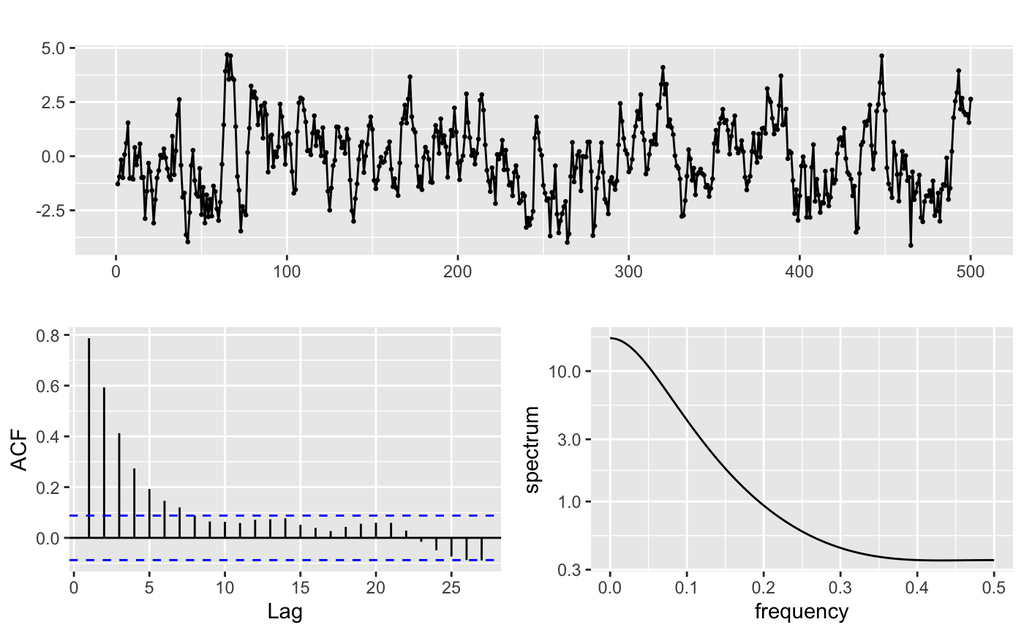

```r
library(forecast)
ggtsdisplay(ts.arma1, plot.type = 'spectrum')
```

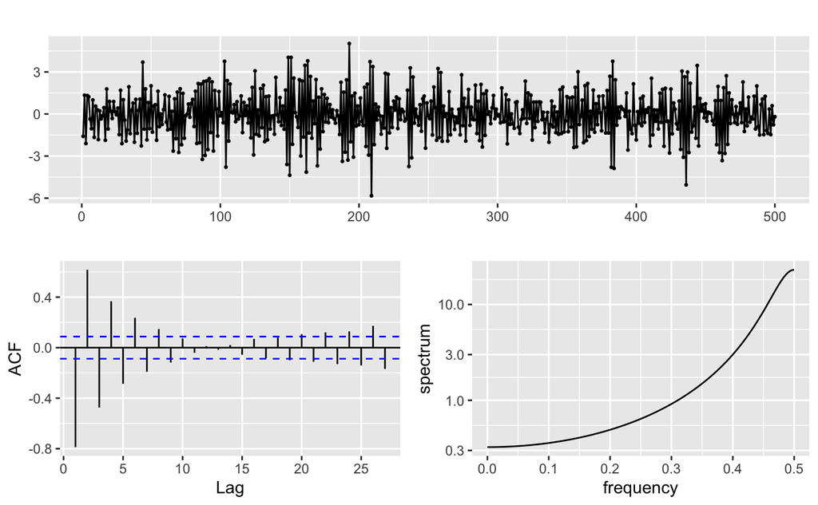

```r
ggtsdisplay(ts.arma2, plot.type = 'spectrum')
```

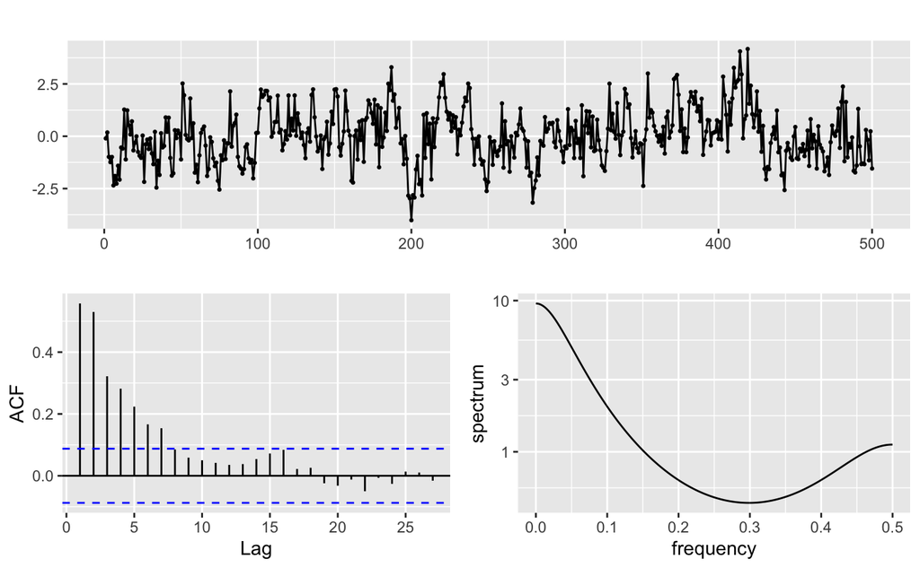

```r
ggtsdisplay(ts.arma3, plot.type = 'spectrum')
```

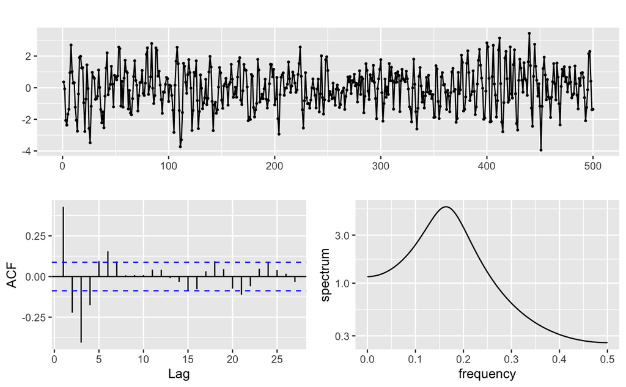

```r
ggtsdisplay(ts.arma4, plot.type = 'spectrum')
```

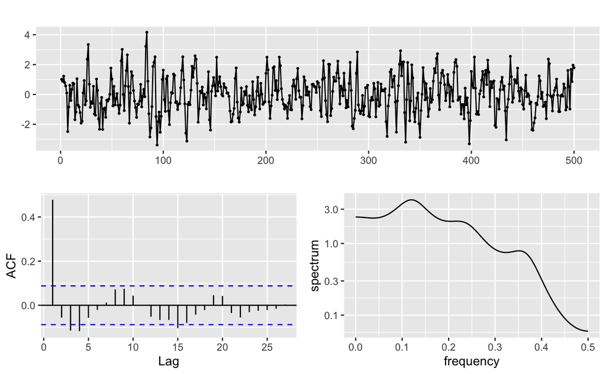

```r
ggtsdisplay(ts.arma5, plot.type = 'spectrum')
```

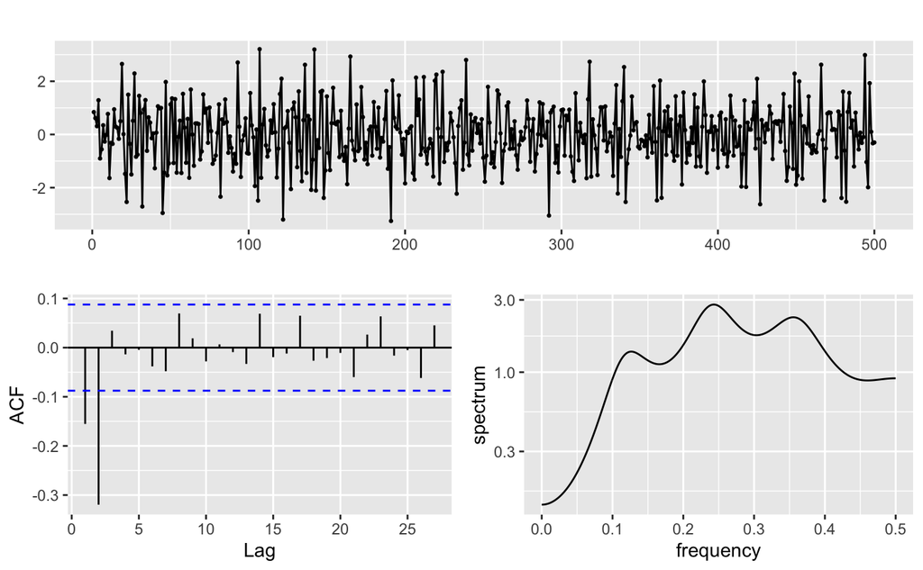

```r
ggtsdisplay(ts.arma6, plot.type = 'spectrum')
```

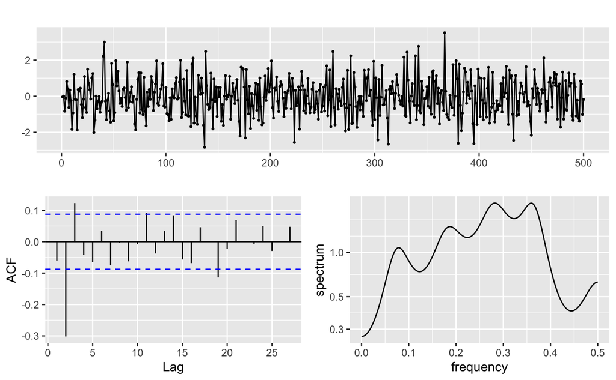

```r
ggtsdisplay(ts.arma7, plot.type = 'spectrum')
```

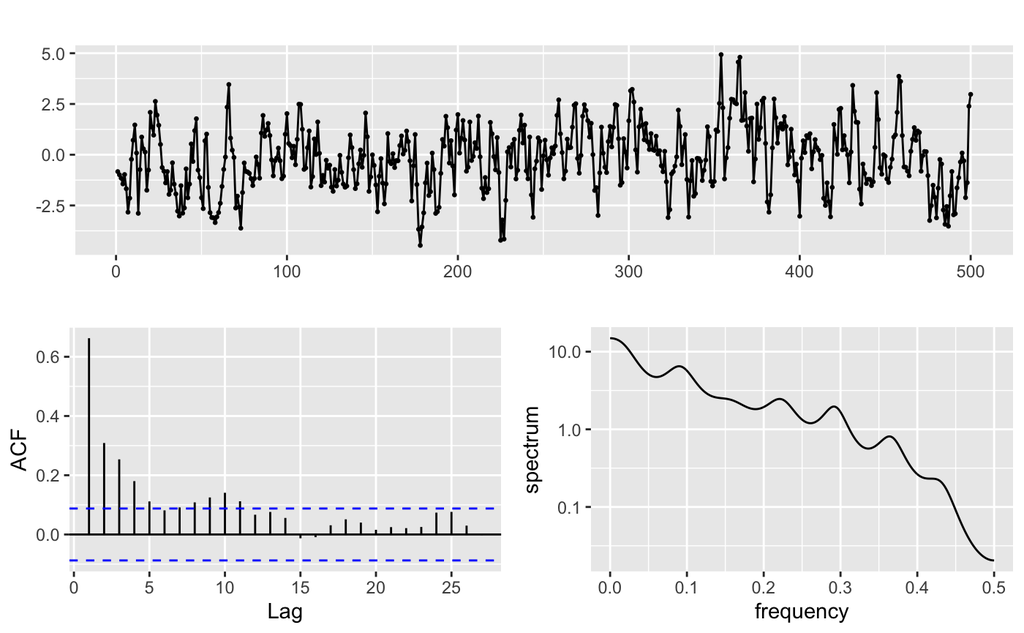

```r
ggtsdisplay(ts.arma8, plot.type = 'spectrum')
```

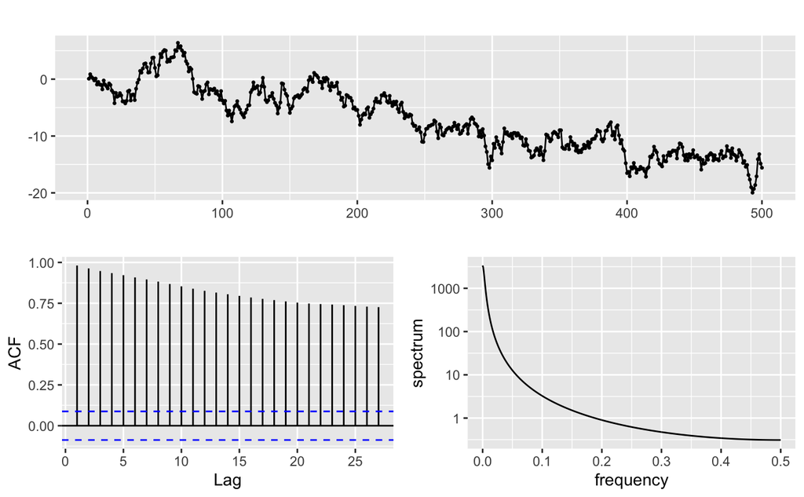

```r
ggtsdisplay(ts.arma9, plot.type = 'spectrum')
```

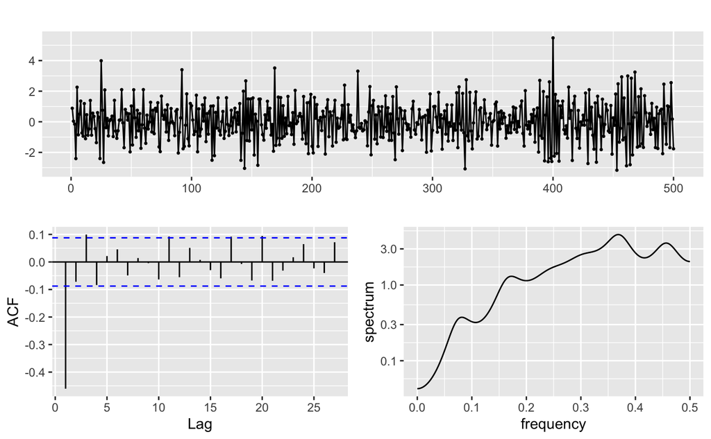

```r
ggtsdisplay(ts.arma10, plot.type = 'spectrum')
```

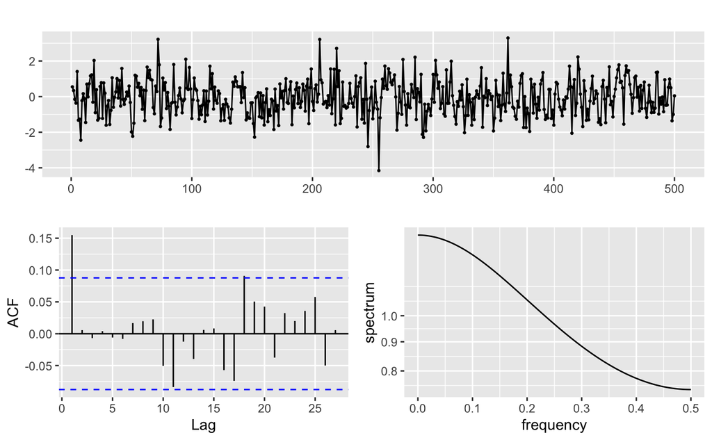

```r
ggtsdisplay(ts.arma11, plot.type = 'spectrum')
```

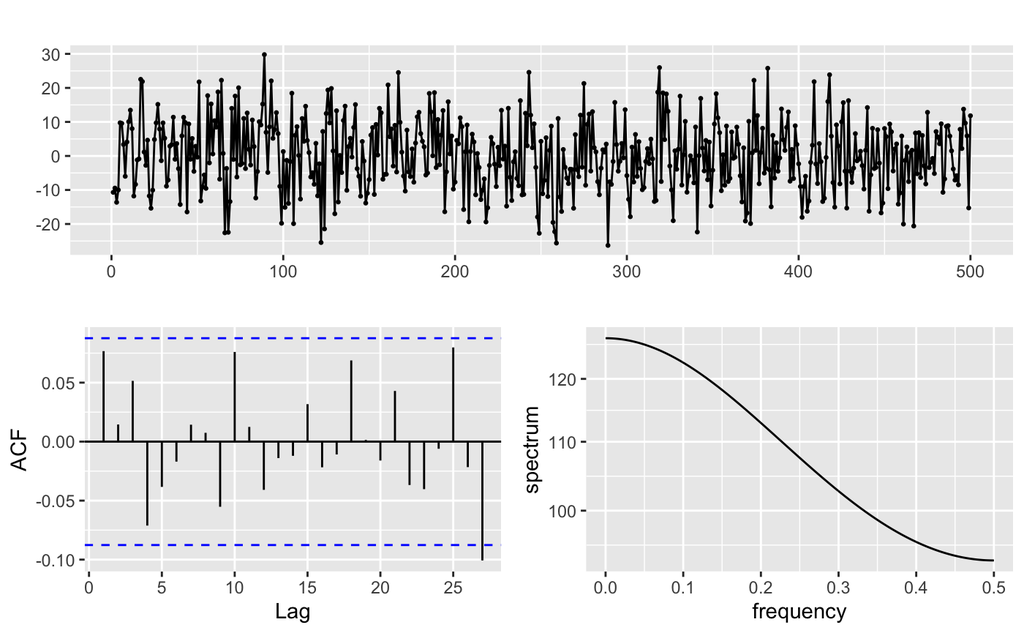

```r
ggtsdisplay(ts.arma12, plot.type = 'spectrum')
```